# ERGM

Joshua Clark

10/13/2015

As is traditional in ergm tutorials, we’ll use the Padgett florentine marriage & business ties dataset included with the ergm package:

```r
library(ergm)
data(florentine)
```

The data contains two network objects - one with marital and another one with business relationships between Florentine families.

```r
flobusiness
```

```
##  Network attributes:
##   vertices = 16
##   directed = FALSE
##   hyper = FALSE
##   loops = FALSE
##   multiple = FALSE
##   bipartite = FALSE
##   total edges= 15
##     missing edges= 0
##     non-missing edges= 15
##
##  Vertex attribute names:
##     priorates totalties vertex.names wealth
##
## No edge attributes
```

```r
flomarriage
```

```
##  Network attributes:
##   vertices = 16
##   directed = FALSE
##   hyper = FALSE
##   loops = FALSE
##   multiple = FALSE
##   bipartite = FALSE
##   total edges= 20
##     missing edges= 0
##     non-missing edges= 20
##
##  Vertex attribute names:
##     priorates totalties vertex.names wealth
##
## No edge attributes
```

Exponential random graph models - what terms can we use in a model?

```r
help('ergm-terms')
```

Let’s estimate a simple model which only examines density (edge term) the format of the ergm command is ergm(YourNetwork ~ Signature1 + Signature2 + …) where YourNetwork can be a matrix or a network object.

```r
flo.mar.1 <- ergm(flomarriage ~ edges)
flo.mar.1
```

```
##
## MLE Coefficients:
##  edges
## -1.609
```

```r
summary(flo.mar.1)
```

```
##
## ==========================
## Summary of model fit
## ==========================
##
## Formula:   flomarriage ~ edges
##
## Iterations:  5 out of 20
##
## Monte Carlo MLE Results:
##       Estimate Std. Error MCMC % p-value
## edges  -1.6094     0.2449      0  <1e-04 ***
## ---
## Signif. codes:  0 '***' 0.001 '**' 0.01 '*' 0.05 '.' 0.1 ' ' 1
##
##      Null Deviance: 166.4  on 120  degrees of freedom
##  Residual Deviance: 108.1  on 119  degrees of freedom
##
## AIC: 110.1    BIC: 112.9    (Smaller is better.)
```

We get a negative edge parameter since the network is rather sparse. The edge parameter here is the log of the edge odds, i.e. log(dyads-w-edge/dyads-no-edge. The network has 20 ties of 120 possible ties. Let’s calculate the log odds ourselves: remember that an event with probability p has odds of p/(1-p) and log odds of log(p/(1-p)).

```r
log(20/(120-20)) # We get -1.609, the same as the edge parameter in the erg model.
```

```
## [1] -1.609438
```

```r
# The corresponding probability is .167:
exp(-1.609)/(1+exp(-1.609)) # you can also get that using inv.logit() from package "boot"
```

```
## [1] 0.1667275
```

Next we look at a fancier model that includes triangles in addition to edges:

```r
flo.mar.2 <- ergm(flomarriage ~ edges + triangles, control=control.ergm(seed=1))
```

```
## Starting maximum likelihood estimation via MCMLE:
## Iteration 1 of at most 20:
## The log-likelihood improved by 0.005741
## Step length converged once. Increasing MCMC sample size.
## Iteration 2 of at most 20:
## The log-likelihood improved by 0.001702
## Step length converged twice. Stopping.
##
## This model was fit using MCMC.  To examine model diagnostics and check for degeneracy, use the mcmc.diagnostics() function.
```

```r
flo.mar.2
```

```
## MCMC sample of size based on:
##    edges  triangle
##  -1.6686    0.1633
##
## Monte Carlo MLE Coefficients:
##    edges  triangle
##  -1.6718    0.1453
```

```r
summary(flo.mar.2)
```

```
##
## ==========================
## Summary of model fit
## ==========================
##
## Formula:   flomarriage ~ edges + triangles
##
## Iterations:  2 out of 20
##
## Monte Carlo MLE Results:
##          Estimate Std. Error MCMC % p-value
## edges     -1.6718     0.3490      0  <1e-04 ***
## triangle   0.1453     0.5959      0   0.808
## ---
## Signif. codes:  0 '***' 0.001 '**' 0.01 '*' 0.05 '.' 0.1 ' ' 1
##
##      Null Deviance: 166.4  on 120  degrees of freedom
##  Residual Deviance: 108.1  on 118  degrees of freedom
##
## AIC: 112.1    BIC: 117.7    (Smaller is better.)
```

The triangle coefficient is not significant - so this is not a signature driving the network formation. What do the coefficients tell us?

There are a large number of other structural signatures you could add paramteters for. For instance 2-stars: kstar(2), 3-stars: kstar(3) isolates: isolates, etc.

Let’s run a model checking whether edges in the Florentine business network are predicted by edges in the marriage network. To do that, we can use an edge covariate parameter edgecov()

As in: ergm(MyNetwork ~ Signature1 + Signature2 + … + edgecov(AnotherNetwork))

```r
flo.mar.3 <- ergm(flobusiness ~ edges + edgecov(flomarriage), control=control.ergm(seed=1))
flo.mar.3
```

```
##
## MLE Coefficients:
##               edges  edgecov.flomarriage
##              -2.587                2.181
```

```r
summary(flo.mar.3)
```

```
##
## ==========================
## Summary of model fit
## ==========================
##
## Formula:   flobusiness ~ edges + edgecov(flomarriage)
##
## Iterations:  5 out of 20
##
## Monte Carlo MLE Results:
##                     Estimate Std. Error MCMC %  p-value
## edges                -2.5867     0.3919      0  < 1e-04 ***
## edgecov.flomarriage   2.1812     0.6016      0 0.000427 ***
## ---
## Signif. codes:  0 '***' 0.001 '**' 0.01 '*' 0.05 '.' 0.1 ' ' 1
##
##      Null Deviance: 166.36  on 120  degrees of freedom
##  Residual Deviance:  77.65  on 118  degrees of freedom
##
## AIC: 81.65    BIC: 87.22    (Smaller is better.)
```

We can also use node attributes in an erg model. For the Florentine families, we have an attribute called “wealth” in the network object.

```r
w.vec <- flomarriage %v% 'wealth'  # Store the node wealth in a numeric vector.
w.vec
```

```
##  [1]  10  36  55  44  20  32   8  42 103  48  49   3  27  10 146  48
```

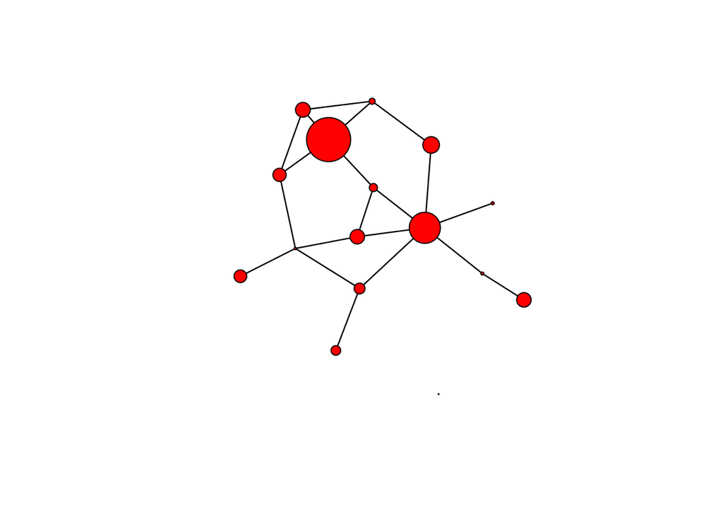

```r
plot(flomarriage, vertex.cex=w.vec/20)  # plot the network with vertex size proportional to wealth
```

Let’s test whether the edge probabilities are a function of wealth: Are wealthy families more likely to form ties?

```r
flo.mar.4 <- ergm(flomarriage ~ edges + nodecov("wealth"), control=control.ergm(seed=1))
flo.mar.4
```

```
##
## MLE Coefficients:
##          edges  nodecov.wealth
##       -2.59493         0.01055
```

```r
summary(flo.mar.4)
```

```
##
## ==========================
## Summary of model fit
## ==========================
##
## Formula:   flomarriage ~ edges + nodecov("wealth")
##
## Iterations:  4 out of 20
##
## Monte Carlo MLE Results:
##                 Estimate Std. Error MCMC % p-value
## edges          -2.594929   0.536056      0  <1e-04 ***
## nodecov.wealth  0.010546   0.004674      0  0.0259 *
## ---
## Signif. codes:  0 '***' 0.001 '**' 0.01 '*' 0.05 '.' 0.1 ' ' 1
##
##      Null Deviance: 166.4  on 120  degrees of freedom
##  Residual Deviance: 103.1  on 118  degrees of freedom
##
## AIC: 107.1    BIC: 112.7    (Smaller is better.)
```

Yes, there is a significant positive main effect for wealth: - The p-value for the wealth parameter makes it significant at the .05 level. - It’s positive, which means we see more of that configuratoin than we’d expect by chance.

### ERGM on a directed network: Sampson Monastery

ERG model of a directed network - the liking relations between monks in Sampson’s dataset.

```r
data(samplk)
samplk1
```

```
##  Network attributes:
##   vertices = 18
##   directed = TRUE
##   hyper = FALSE
##   loops = FALSE
##   multiple = FALSE
##   bipartite = FALSE
##   total edges= 55
##     missing edges= 0
##     non-missing edges= 55
##
##  Vertex attribute names:
##     cloisterville group vertex.names
##
## No edge attributes
```

```r
samplk2
```

```
##  Network attributes:
##   vertices = 18
##   directed = TRUE
##   hyper = FALSE
##   loops = FALSE
##   multiple = FALSE
##   bipartite = FALSE
##   total edges= 57
##     missing edges= 0
##     non-missing edges= 57
##
##  Vertex attribute names:
##     cloisterville group vertex.names
##
## No edge attributes
```

```r
samplk3
```

```
##  Network attributes:
##   vertices = 18
##   directed = TRUE
##   hyper = FALSE
##   loops = FALSE
##   multiple = FALSE
##   bipartite = FALSE
##   total edges= 56
##     missing edges= 0
##     non-missing edges= 56
##
##  Vertex attribute names:
##     cloisterville group vertex.names
##
## No edge attributes
```

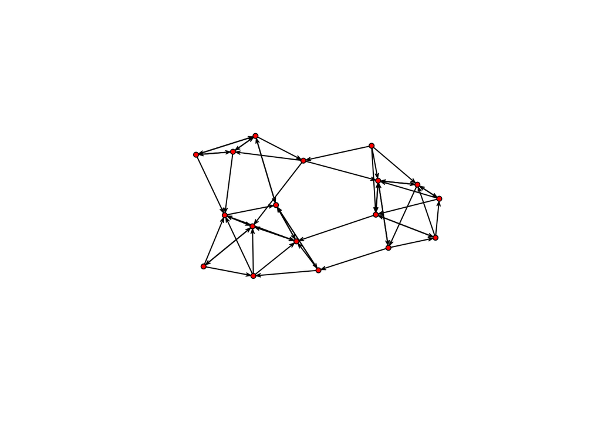

```r
plot(samplk3)
```

Is there a statistically significant tendency for ties to be reciprocated?

```r
samp.mod.1 <- ergm(samplk3 ~ edges + mutual, control=control.ergm(seed=1))
```

```
## Starting maximum likelihood estimation via MCMLE:
## Iteration 1 of at most 20:
## The log-likelihood improved by 0.0006404
## Step length converged once. Increasing MCMC sample size.
## Iteration 2 of at most 20:
## The log-likelihood improved by 0.0005745
## Step length converged twice. Stopping.
##
## This model was fit using MCMC.  To examine model diagnostics and check for degeneracy, use the mcmc.diagnostics() function.
```

```r
summary(samp.mod.1)
```

```
##
## ==========================
## Summary of model fit
## ==========================
##
## Formula:   samplk3 ~ edges + mutual
##
## Iterations:  2 out of 20
##
## Monte Carlo MLE Results:
##        Estimate Std. Error MCMC % p-value
## edges   -2.1538     0.2176      0  <1e-04 ***
## mutual   2.2968     0.4754      0  <1e-04 ***
## ---
## Signif. codes:  0 '***' 0.001 '**' 0.01 '*' 0.05 '.' 0.1 ' ' 1
##
##      Null Deviance: 424.2  on 306  degrees of freedom
##  Residual Deviance: 268.2  on 304  degrees of freedom
##
## AIC: 272.2    BIC: 279.6    (Smaller is better.)
```

Conditional log-odds of two actors forming a tie = -2.15 * change in the number of ties + 2.3 * change in number of mutual dyads.

If adding the tie will not make a dyad reciprocal, its log-odds = -2.15 If it will add a mutual dyad to the network, its log-odds = -2.15 + 2.3 = 0.15

### ERGM with node attributes: Faux Mesa High

Faux mesa high is simulated data representing a high-school friendship network. Attributes for each node (student) include gender, race, and grade.

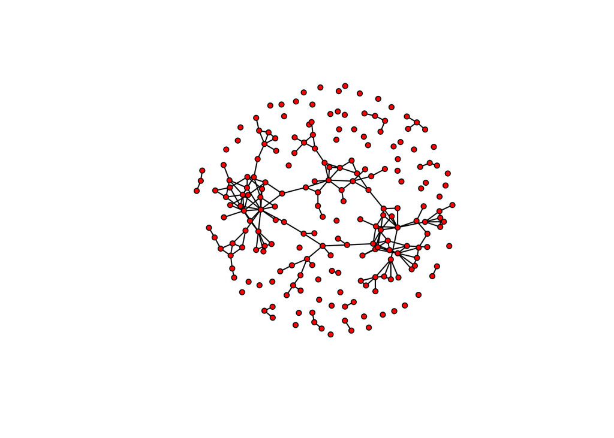

```r
data(faux.mesa.high)
fmh.net <- faux.mesa.high
plot(fmh.net)
```

```r
fmh.net
```

```
##  Network attributes:
##   vertices = 205
##   directed = FALSE
##   hyper = FALSE
##   loops = FALSE
##   multiple = FALSE
##   bipartite = FALSE
##   total edges= 203
##     missing edges= 0
##     non-missing edges= 203
##
##  Vertex attribute names:
##     Grade Race Sex
##
## No edge attributes
```

Taking a look at gender.

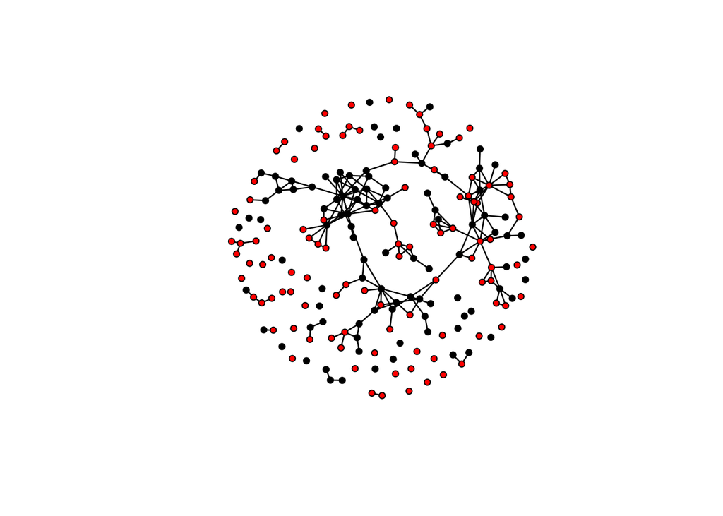

```r
plot(fmh.net, vertex.col='Sex')
```

Taking a look at the grade of the students

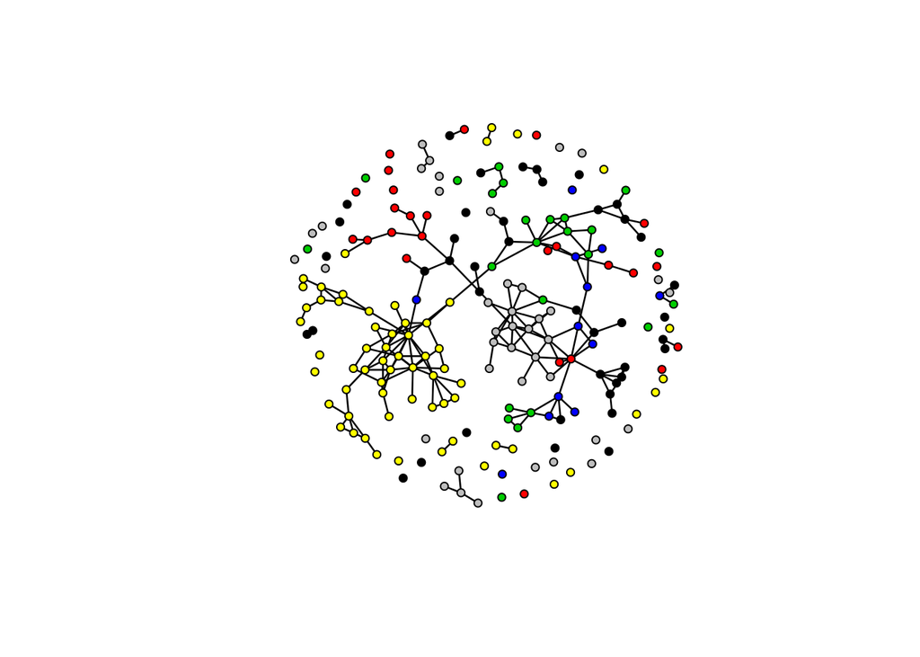

```r
plot(fmh.net, vertex.col='Grade')
```

Taking a look at the race of the students

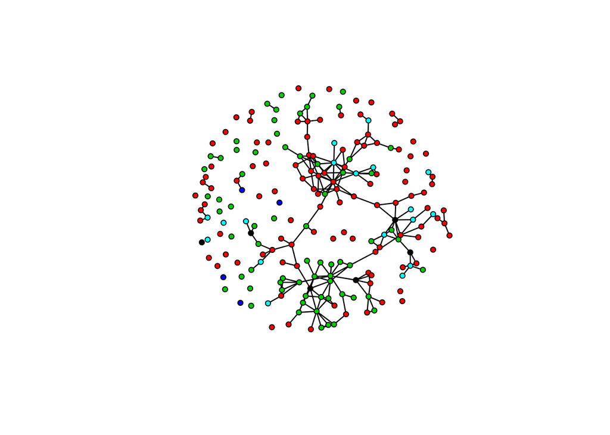

```r
plot(fmh.net, vertex.col='Race')
```

A simple model that includes just the edge (density) parameter:

```r
fmh.mod.1 <- ergm(fmh.net ~ edges)
summary(fmh.mod.1)
```

```
##
## ==========================
## Summary of model fit
## ==========================
##
## Formula:   fmh.net ~ edges
##
## Iterations:  7 out of 20
##
## Monte Carlo MLE Results:
##       Estimate Std. Error MCMC % p-value
## edges -4.62502    0.07053      0  <1e-04 ***
## ---
## Signif. codes:  0 '***' 0.001 '**' 0.01 '*' 0.05 '.' 0.1 ' ' 1
##
##      Null Deviance: 28987  on 20910  degrees of freedom
##  Residual Deviance:  2286  on 20909  degrees of freedom
##
## AIC: 2288    BIC: 2296    (Smaller is better.)
```

**NODEMATCH**

Are nodes with the same attribute levels more likely to be connected?

Do high-school students tend to have friends of the same grade?

```r
fmh.mod.2 <- ergm(fmh.net ~ edges + nodematch("Grade"), control=control.ergm(seed=1))
summary(fmh.mod.2)
```

```
##
## ==========================
## Summary of model fit
## ==========================
##
## Formula:   fmh.net ~ edges + nodematch("Grade")
##
## Iterations:  8 out of 20
##
## Monte Carlo MLE Results:
##                 Estimate Std. Error MCMC % p-value
## edges            -6.0340     0.1583      0  <1e-04 ***
## nodematch.Grade   2.8310     0.1773      0  <1e-04 ***
## ---
## Signif. codes:  0 '***' 0.001 '**' 0.01 '*' 0.05 '.' 0.1 ' ' 1
##
##      Null Deviance: 28987  on 20910  degrees of freedom
##  Residual Deviance:  1940  on 20908  degrees of freedom
##
## AIC: 1944    BIC: 1959    (Smaller is better.)
```

We can add an attribute diff=T to nodematch to get a separate parameter for each level of the categorical variable. Here, a separate parameter for each grade:

```r
fmh.mod.3 <- ergm(fmh.net ~ edges + nodematch("Grade", diff=T), control=control.ergm(seed=1))
summary(fmh.mod.3)
```

```
##
## ==========================
## Summary of model fit
## ==========================
##
## Formula:   fmh.net ~ edges + nodematch("Grade", diff = T)
##
## Iterations:  8 out of 20
##
## Monte Carlo MLE Results:
##                    Estimate Std. Error MCMC % p-value
## edges               -6.0340     0.1583      0  <1e-04 ***
## nodematch.Grade.7    2.8471     0.1973      0  <1e-04 ***
## nodematch.Grade.8    2.9145     0.2381      0  <1e-04 ***
## nodematch.Grade.9    2.4385     0.2641      0  <1e-04 ***
## nodematch.Grade.10   2.5579     0.3736      0  <1e-04 ***
## nodematch.Grade.11   3.3104     0.2962      0  <1e-04 ***
## nodematch.Grade.12   3.7315     0.4565      0  <1e-04 ***
## ---
## Signif. codes:  0 '***' 0.001 '**' 0.01 '*' 0.05 '.' 0.1 ' ' 1
##
##      Null Deviance: 28987  on 20910  degrees of freedom
##  Residual Deviance:  1928  on 20903  degrees of freedom
##
## AIC: 1942    BIC: 1998    (Smaller is better.)
```

How about gender and race?

```r
fmh.mod.4 <- ergm(fmh.net ~ edges + nodematch("Grade") + nodematch("Race") + nodematch("Sex"), control=control.ergm(seed=1))
summary(fmh.mod.4)
```

```
##
## ==========================
## Summary of model fit
## ==========================
##
## Formula:   fmh.net ~ edges + nodematch("Grade") + nodematch("Race") + nodematch("Sex")
##
## Iterations:  7 out of 20
##
## Monte Carlo MLE Results:
##                 Estimate Std. Error MCMC % p-value
## edges            -6.6006     0.1999      0 < 1e-04 ***
## nodematch.Grade   2.8307     0.1774      0 < 1e-04 ***
## nodematch.Race    0.4332     0.1430      0 0.00245 **
## nodematch.Sex     0.6447     0.1495      0 < 1e-04 ***
## ---
## Signif. codes:  0 '***' 0.001 '**' 0.01 '*' 0.05 '.' 0.1 ' ' 1
##
##      Null Deviance: 28987  on 20910  degrees of freedom
##  Residual Deviance:  1911  on 20906  degrees of freedom
##
## AIC: 1919    BIC: 1951    (Smaller is better.)
```

**NODEMIX**

Nodemix will add a parameter for each combination of levels for the categorical variable. Let’s look at the parameters for edges between students from different race groups:

```r
fmh.mod.5 <- ergm(fmh.net ~ edges + nodemix("Race"), control=control.ergm(seed=1))
```

```
## Observed statistic(s) mix.Race.Black.Black, mix.Race.Black.Other, mix.Race.NatAm.Other, mix.Race.Other.Other, and mix.Race.Other.White are at their smallest attainable values. Their coefficients will be fixed at -Inf.
```

```r
summary(fmh.mod.5)
```

```
##
## ==========================
## Summary of model fit
## ==========================
##
## Formula:   fmh.net ~ edges + nodemix("Race")
##
## Iterations:  7 out of 20
##
## Monte Carlo MLE Results:
##                      Estimate Std. Error MCMC % p-value
## edges                 -3.6177     0.5067      0  <1e-04 ***
## mix.Race.Black.Black     -Inf     0.0000      0  <1e-04 ***
## mix.Race.Black.Hisp   -0.7737     0.6191      0  0.2114
## mix.Race.Hisp.Hisp    -1.0833     0.5251      0  0.0391 *
## mix.Race.Black.NatAm   0.2037     0.5798      0  0.7253
## mix.Race.Hisp.NatAm   -1.5741     0.5303      0  0.0030 **
## mix.Race.NatAm.NatAm  -0.2644     0.5281      0  0.6167
## mix.Race.Black.Other     -Inf     0.0000      0  <1e-04 ***
## mix.Race.Hisp.Other   -2.4577     1.1221      0  0.0285 *
## mix.Race.NatAm.Other     -Inf     0.0000      0  <1e-04 ***
## mix.Race.Other.Other     -Inf     0.0000      0  <1e-04 ***
## mix.Race.Black.White   0.5924     0.6829      0  0.3858
## mix.Race.Hisp.White   -0.8617     0.5502      0  0.1173
## mix.Race.NatAm.White  -1.1814     0.5979      0  0.0482 *
## mix.Race.Other.White     -Inf     0.0000      0  <1e-04 ***
## mix.Race.White.White       NA     0.0000      0      NA
## ---
## Signif. codes:  0 '***' 0.001 '**' 0.01 '*' 0.05 '.' 0.1 ' ' 1
##
##      Null Deviance: 28987  on 20910  degrees of freedom
##  Residual Deviance:  2753  on 20894  degrees of freedom
##
## AIC: 2785    BIC: 2912    (Smaller is better.)
##
##  Warning: The following terms have infinite coefficient estimates:
##   mix.Race.Black.Black mix.Race.Black.Other mix.Race.NatAm.Other mix.Race.Other.Other mix.Race.Other.White
```

```r
table(fmh.net %v% "Race")           # Check out race frequencies
```

```
##
## Black  Hisp NatAm Other White
##     6   109    68     4    18
```

```r
mixingmatrix(fmh.net, "Race")   # Check out # of links between/within groups
```

```
## Note:  Marginal totals can be misleading
##  for undirected mixing matrices.
##       Black Hisp NatAm Other White
## Black     0    8    13     0     5
## Hisp      8   53    41     1    22
## NatAm    13   41    46     0    10
## Other     0    1     0     0     0
## White     5   22    10     0     4
```

Note that we got -Inf parameters in the model for configurations that don’t exist in the observed network at all.

**NODEFACTOR**

Main effect of a categorical attribute. Are some types of nodes more likely to form ties than others? For example, are boys forming friendship ties more actively than girls?

```r
fmh.mod.6 <- ergm(fmh.net ~ edges + nodematch("Grade", diff = T) + nodefactor("Sex"), control=control.ergm(seed=1))
summary(fmh.mod.6)
```

```
##
## ==========================
## Summary of model fit
## ==========================
##
## Formula:   fmh.net ~ edges + nodematch("Grade", diff = T) + nodefactor("Sex")
##
## Iterations:  8 out of 20
##
## Monte Carlo MLE Results:
##                    Estimate Std. Error MCMC %  p-value
## edges               -5.6784     0.1820      0  < 1e-04 ***
## nodematch.Grade.7    2.7869     0.1981      0  < 1e-04 ***
## nodematch.Grade.8    2.9969     0.2395      0  < 1e-04 ***
## nodematch.Grade.9    2.4074     0.2643      0  < 1e-04 ***
## nodematch.Grade.10   2.6208     0.3744      0  < 1e-04 ***
## nodematch.Grade.11   3.3627     0.2971      0  < 1e-04 ***
## nodematch.Grade.12   3.6628     0.4578      0  < 1e-04 ***
## nodefactor.Sex.M    -0.3743     0.1047      0 0.000351 ***
## ---
## Signif. codes:  0 '***' 0.001 '**' 0.01 '*' 0.05 '.' 0.1 ' ' 1
##
##      Null Deviance: 28987  on 20910  degrees of freedom
##  Residual Deviance:  1915  on 20902  degrees of freedom
##
## AIC: 1931    BIC: 1995    (Smaller is better.)
```

Negative parameter for males means females are more actively forming friendships.

**NODECOV**

Main effect of a continuous attribute (we’ll treat grade as continuous here). Are nodes with high levels on a continuous attribute more likely to form ties? Let’s check if students with higher values on attribute “Grade” tend to form more friendships.

```r
fmh.mod.7 <- ergm(fmh.net ~ edges + nodecov("Grade") + nodematch("Sex"), control=control.ergm(seed=1))
summary(fmh.mod.7)
```

```
##
## ==========================
## Summary of model fit
## ==========================
##
## Formula:   fmh.net ~ edges + nodecov("Grade") + nodematch("Sex")
##
## Iterations:  7 out of 20
##
## Monte Carlo MLE Results:
##               Estimate Std. Error MCMC % p-value
## edges         -4.00245    0.57593      0  <1e-04 ***
## nodecov.Grade -0.05696    0.03278      0  0.0823 .
## nodematch.Sex  0.63427    0.14784      0  <1e-04 ***
## ---
## Signif. codes:  0 '***' 0.001 '**' 0.01 '*' 0.05 '.' 0.1 ' ' 1
##
##      Null Deviance: 28987  on 20910  degrees of freedom
##  Residual Deviance:  2263  on 20907  degrees of freedom
##
## AIC: 2269    BIC: 2293    (Smaller is better.)
```

Note that this is the parameter version for undirected networks. For directed networks, we have nodeicov (for incoming links) and nodeocov (for outgoing links). Similarly nodefactor has directev versions nodeifactor & nodeofactor.

**ABSDIFF**

For continuous attributes: are people more likely to be connected to others who have similar values on an attribute? Absdiff = abs(ValueNode1-ValueNode2). Here, are students more likely to have friends close to their own grade? that is, links i->j are more likely for smaller values of abs(grade of i - grade of j))

```r
fmh.mod.8 <- ergm(fmh.net ~ edges + absdiff("Grade") + nodematch("Sex"), control=control.ergm(seed=1))
summary(fmh.mod.8)
```

```
##
## ==========================
## Summary of model fit
## ==========================
##
## Formula:   fmh.net ~ edges + absdiff("Grade") + nodematch("Sex")
##
## Iterations:  7 out of 20
##
## Monte Carlo MLE Results:
##               Estimate Std. Error MCMC % p-value
## edges          -3.7389     0.1274      0  <1e-04 ***
## absdiff.Grade  -1.3866     0.1106      0  <1e-04 ***
## nodematch.Sex   0.6416     0.1489      0  <1e-04 ***
## ---
## Signif. codes:  0 '***' 0.001 '**' 0.01 '*' 0.05 '.' 0.1 ' ' 1
##
##      Null Deviance: 28987  on 20910  degrees of freedom
##  Residual Deviance:  1979  on 20907  degrees of freedom
##
## AIC: 1985    BIC: 2009    (Smaller is better.)
```

### Simulating networks based on a model

After we have estimated model coefficients, we can draw graphs from the probability distribution defined by those parameter values. If our model was good, the graphs we draw from this distribution should be similar to our observed data.

```r
fmh.mod.8.sim <- simulate(fmh.mod.8, nsim=15)
summary(fmh.mod.8.sim)
```

```
## Number of Networks: 15
## Model: fmh.net ~ edges + absdiff("Grade") + nodematch("Sex")
## Reference: ~Bernoulli
## Constraints: ~.
## Parameters:
##         edges absdiff.Grade nodematch.Sex
##    -3.7389020    -1.3866379     0.6416154
##
## Stored network statistics:
##       edges absdiff.Grade nodematch.Sex
##  [1,]   205            79           134
##  [2,]   191            76           129
##  [3,]   201            68           126
##  [4,]   187            53           117
##  [5,]   203            68           132
##  [6,]   195            68           121
##  [7,]   211            80           152
##  [8,]   199            78           128
##  [9,]   184            69           127
## [10,]   167            59           107
## [11,]   219            83           142
## [12,]   177            72           111
## [13,]   194            80           115
## [14,]   190            68           117
## [15,]   198            78           123
```

```r
#' All the simulated network are stored in the returned object:
class(fmh.mod.8.sim)
```

```
## [1] "network.list"
```

```r
#' We can access any of them and take a look at it:
fmh.mod.8.sim[[1]]
```

```
##  Network attributes:
##   vertices = 205
##   directed = FALSE
##   hyper = FALSE
##   loops = FALSE
##   multiple = FALSE
##   bipartite = FALSE
##   total edges= 205
##     missing edges= 0
##     non-missing edges= 205
##
##  Vertex attribute names:
##     Grade Race Sex vertex.names
##
## No edge attributes
```

### Goodnes of Fit and MCMC diagnostics

After estimating parameters for your mode, you want to know how well it fits the observed data.

Let’s check the goodness of fit for one of our initial models of the Padgett network. Check how well the degree distribution of the networs generated from our model match the degree distribution of the observed network:

```r
summary(flo.mar.4) # Take a look at the model
```

```
##
## ==========================
## Summary of model fit
## ==========================
##
## Formula:   flomarriage ~ edges + nodecov("wealth")
##
## Iterations:  4 out of 20
##
## Monte Carlo MLE Results:
##                 Estimate Std. Error MCMC % p-value
## edges          -2.594929   0.536056      0  <1e-04 ***
## nodecov.wealth  0.010546   0.004674      0  0.0259 *
## ---
## Signif. codes:  0 '***' 0.001 '**' 0.01 '*' 0.05 '.' 0.1 ' ' 1
##
##      Null Deviance: 166.4  on 120  degrees of freedom
##  Residual Deviance: 103.1  on 118  degrees of freedom
##
## AIC: 107.1    BIC: 112.7    (Smaller is better.)
```

```r
flo.mar.4.gof <- gof(flo.mar.4 ~ degree) # goodness of fit for degree distribution
```

If this was a directed network, we could check gof for in- or out-degree instead using gof(flo.mar.4 ~ idegree) or gof(flo.mar.4 ~ odegree)

```r
flo.mar.4.gof # Take a look at the observed & simulated values
```

```
##
## Goodness-of-fit for degree
##
##   obs min mean max MC p-value
## 0   1   0 1.42   6       1.00
## 1   4   0 3.56   9       1.00
## 2   2   1 3.92   8       0.44
## 3   6   0 3.30   8       0.14
## 4   2   0 2.01   6       1.00
## 5   0   0 0.95   3       0.68
## 6   1   0 0.59   3       0.88
## 7   0   0 0.19   1       1.00
## 8   0   0 0.04   1       1.00
## 9   0   0 0.02   1       1.00
```

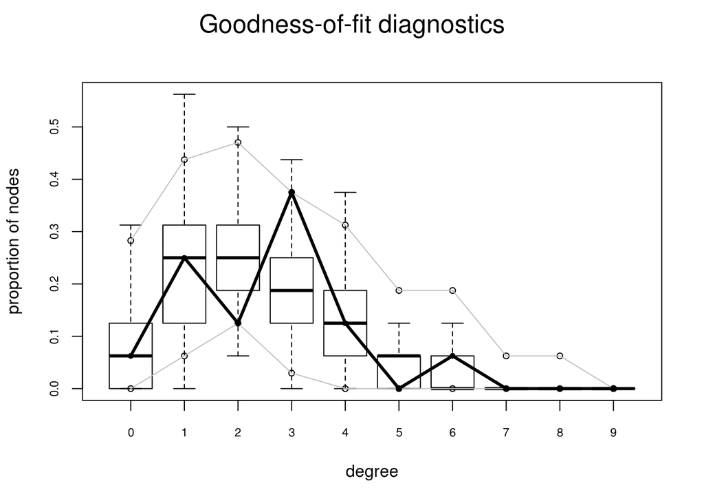

```r
plot(flo.mar.4.gof) # plot the observed & simulated values
```

The resutls contain 1 row for each possible node degree (e.g. row 0 - number of isolates, row 1 - number of nodes with only 1 link, row 2 - # of nodes with 2 links, etc.)

The first column contains the counts from the observed network, the other give staticstics from the simulated networks.

The fit is not bad - observed values are within the confidence interval (see the plot). P values are high (the observed & simulated values do not differ significantly). This is one of those rare cases where a high p value is a good thing :)

We can check the goodness of fit with regard to other network statistics. For instance geodesic distance.

Compare our network with 20 simulated networks based on the flo.mar.4 model:

```r
flo.mar.4.gof2 <- gof(flo.mar.4 ~ distance, nsim=20) # gof based on 20 simulated nets
summary(flo.mar.4.gof2)
```

```
##
## Goodness-of-fit for minimum geodesic distance
##
##     obs min  mean max MC p-value
## 1    20  11 19.33  30       0.96
## 2    35  12 32.59  55       0.88
## 3    32   4 25.30  39       0.42
## 4    15   0 10.81  22       0.60
## 5     3   0  3.45  16       0.86
## 6     0   0  1.16  14       1.00
## 7     0   0  0.31   9       1.00
## 8     0   0  0.11   6       1.00
## 9     0   0  0.01   1       1.00
## Inf  15   0 26.93  90       0.94
```

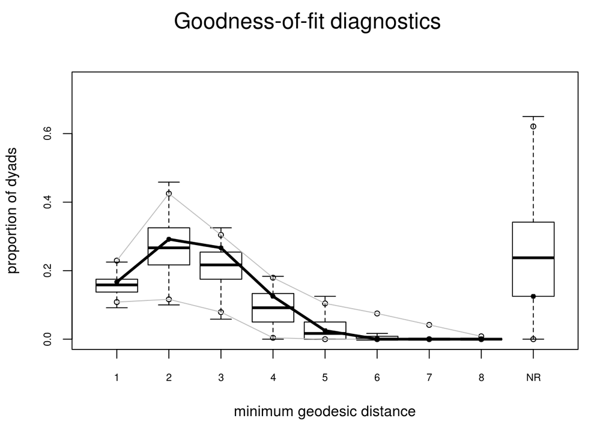

```r
plot(flo.mar.4.gof2)
```

Here each row in the summary is the number of geodesics with a particular length. For instance, we have 20 node pairs in the observed network with shortest paths of 1 (those correspond to the 20 edges in our observed network).

### Model diagnostics (for MCMC)

Information about the model that can help diagnose problems. Note we can’t get (and don’t need) these diagnostics for flo.mar.4 since it was not estimated using MCMC. This is because it was simple enough (i.e. a dyadic independence model) that we did not need MCMC estimation.

```r
mcmc.diagnostics(flo.mar.2)
```

```
## Sample statistics summary:
##
## Iterations = 16384:4209664
## Thinning interval = 1024
## Number of chains = 1
## Sample size per chain = 4096
##
## 1. Empirical mean and standard deviation for each variable,
##    plus standard error of the mean:
##
##            Mean    SD Naive SE Time-series SE
## edges    0.2163 4.370  0.06828        0.06828
## triangle 0.1514 2.627  0.04104        0.03865
##
## 2. Quantiles for each variable:
##
##          2.5% 25% 50% 75% 97.5%
## edges      -8  -3   0   3     9
## triangle   -3  -2   0   1     7
##
##
## Sample statistics cross-correlations:
##              edges  triangle
## edges    1.0000000 0.7557384
## triangle 0.7557384 1.0000000
##
## Sample statistics auto-correlation:
## Chain 1
##                 edges     triangle
## Lag 0     1.000000000  1.000000000
## Lag 1024 -0.003440575  0.004940634
## Lag 2048 -0.018762913 -0.041240633
## Lag 3072  0.017866835  0.022568096
## Lag 4096  0.017150109 -0.004025476
## Lag 5120 -0.022170123 -0.043195178
##
## Sample statistics burn-in diagnostic (Geweke):
## Chain 1
##
## Fraction in 1st window = 0.1
## Fraction in 2nd window = 0.5
##
##    edges triangle
##   -1.674   -1.826
##
## Individual P-values (lower = worse):
##      edges   triangle
## 0.09412376 0.06781938
## Joint P-value (lower = worse):  0.2220303 .
```

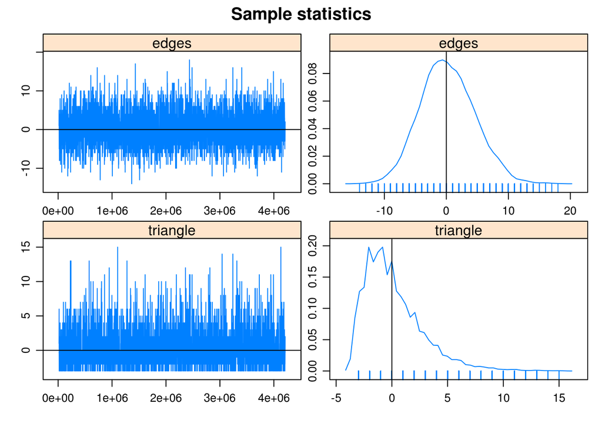

```
##
## Recent changes in the ergm estimation algorithm mean that these plots can no longer be used to ensure that the mean statistics from the model match the observed network statistics. For that functionality, please use the GOF command: gof(ergmFitObject, GOF=~model).
```

We can examine the diagnostics to see whether our model looks ok, check for model degeneracy, see if MCMC sample size and burn-in are large enough, etc. Read more about interpreting model diagnostics in Section 5 of [this document](http://statnet.csde.washington.edu/trac/raw-attachment/wiki/Resources/ERGMtutorial.pdf)

### Degeneracy

Degeneracy happens when the simulation of new networks gets “stuck” and you end up with a lot of garbage networks which don’t reflect the base reality of your data. It is important to find and diagnose these models as they can seriously skew the quality of your work.

Broadly speaking there are two categories of degeneracy. Converging and non-converging. The first occurs when your model fits but the MCMC diagnostics output some weirdness.

```r
flo.degen.1<-ergm(flobusiness~edges+degree(1))
```

```
## Starting maximum likelihood estimation via MCMLE:
## Iteration 1 of at most 20:
## The log-likelihood improved by 0.2919
## Step length converged once. Increasing MCMC sample size.
## Iteration 2 of at most 20:
## The log-likelihood improved by 0.004948
## Step length converged twice. Stopping.
##
## This model was fit using MCMC.  To examine model diagnostics and check for degeneracy, use the mcmc.diagnostics() function.
```

```r
mcmc.diagnostics(flo.degen.1)
```

```
## Sample statistics summary:
##
## Iterations = 16384:4209664
## Thinning interval = 1024
## Number of chains = 1
## Sample size per chain = 4096
##
## 1. Empirical mean and standard deviation for each variable,
##    plus standard error of the mean:
##
##             Mean    SD Naive SE Time-series SE
## edges   -0.18945 3.742  0.05847        0.05847
## degree1 -0.09082 1.620  0.02531        0.02531
##
## 2. Quantiles for each variable:
##
##         2.5% 25% 50% 75% 97.5%
## edges     -8  -3   0   2     7
## degree1   -3  -1   0   1     3
##
##
## Sample statistics cross-correlations:
##             edges   degree1
## edges    1.000000 -0.424192
## degree1 -0.424192  1.000000
##
## Sample statistics auto-correlation:
## Chain 1
##                edges      degree1
## Lag 0    1.000000000  1.000000000
## Lag 1024 0.014352839 -0.013564430
## Lag 2048 0.021819238  0.016723172
## Lag 3072 0.002359504 -0.006494932
## Lag 4096 0.034613433  0.036682710
## Lag 5120 0.024070146 -0.003045585
##
## Sample statistics burn-in diagnostic (Geweke):
## Chain 1
##
## Fraction in 1st window = 0.1
## Fraction in 2nd window = 0.5
##
##   edges degree1
## -0.2491  1.1290
##
## Individual P-values (lower = worse):
##     edges   degree1
## 0.8033080 0.2588818
## Joint P-value (lower = worse):  0.5374597 .
```

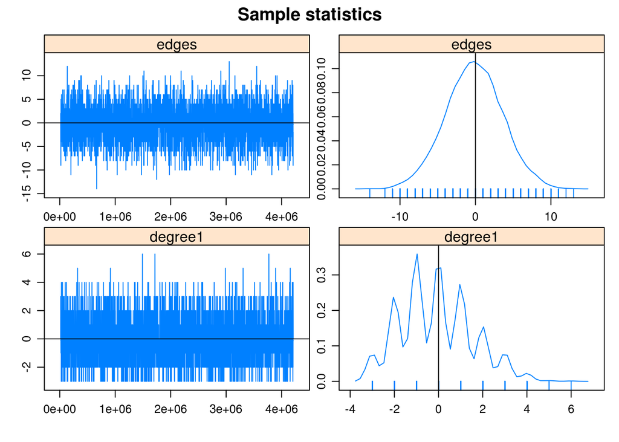

```
##
## Recent changes in the ergm estimation algorithm mean that these plots can no longer be used to ensure that the mean statistics from the model match the observed network statistics. For that functionality, please use the GOF command: gof(ergmFitObject, GOF=~model).
```

Woah, that second graph is super spikey and un-cool looking. We want a smooth fit centered at or around zero. We can fix this simply by dropping degree(1) from the model.

Now the second and objectively more terrifying kind of degenerecy. When everything blows up. Let’s load another fake highschool dataset and fit a model.

```r
data(faux.magnolia.high)
faux.degen.1<- ergm(faux.magnolia.high~edges+triangle)
```

```
## Starting maximum likelihood estimation via MCMLE:
## Iteration 1 of at most 20:
## The log-likelihood improved by 4.411
## Iteration 2 of at most 20:
## The log-likelihood improved by 1.296
## Step length converged once. Increasing MCMC sample size.
## Iteration 3 of at most 20:
```

```
## Error in ergm.MCMLE(init, nw, model, initialfit = (initialfit <- NULL), : Number of edges in a simulated network exceeds that in the observed by a factor of more than 20. This is a strong indicator of model degeneracy or a very poor starting parameter configuration. If you are reasonably certain …
```

Welp. Triangles kinda broke the model. The triangle function is notorious for doing this. There is an alternative GWESP (Geometrically Weighted Edgewise Shared Parameter) which gets at roughly the same process with a lot less pain.

```r
faux.degen.2 <- ergm(faux.magnolia.high~edges+gwesp(0.25,fixed=T))
```

```
## Starting maximum likelihood estimation via MCMLE:
## Iteration 1 of at most 20:
## The log-likelihood improved by 3.855
## Iteration 2 of at most 20:
## The log-likelihood improved by 0.9946
## Step length converged once. Increasing MCMC sample size.
## Iteration 3 of at most 20:
## The log-likelihood improved by 0.2452
## Step length converged twice. Stopping.
##
## This model was fit using MCMC.  To examine model diagnostics and check for degeneracy, use the mcmc.diagnostics() function.
```

```r
mcmc.diagnostics(faux.degen.2)
```

```
## Sample statistics summary:
##
## Iterations = 16384:4209664
## Thinning interval = 1024
## Number of chains = 1
## Sample size per chain = 4096
##
## 1. Empirical mean and standard deviation for each variable,
##    plus standard error of the mean:
##
##                   Mean    SD Naive SE Time-series SE
## edges            25.07 44.44   0.6943          14.56
## gwesp.fixed.0.25 26.56 37.97   0.5933          15.42
##
## 2. Quantiles for each variable:
##
##                    2.5%    25%   50%   75%  97.5%
## edges            -75.00 -1.000 29.00 56.00 101.00
## gwesp.fixed.0.25 -60.72  8.087 34.48 52.27  85.65
##
##
## Sample statistics cross-correlations:
##                      edges gwesp.fixed.0.25
## edges            1.0000000        0.8340429
## gwesp.fixed.0.25 0.8340429        1.0000000
##
## Sample statistics auto-correlation:
## Chain 1
##              edges gwesp.fixed.0.25
## Lag 0    1.0000000        1.0000000
## Lag 1024 0.8764837        0.9970413
## Lag 2048 0.8021090        0.9941843
## Lag 3072 0.7563961        0.9913394
## Lag 4096 0.7303628        0.9885023
## Lag 5120 0.7110029        0.9856577
##
## Sample statistics burn-in diagnostic (Geweke):
## Chain 1
##
## Fraction in 1st window = 0.1
## Fraction in 2nd window = 0.5
##
##            edges gwesp.fixed.0.25
##           -1.855           -1.088
##
## Individual P-values (lower = worse):
##            edges gwesp.fixed.0.25
##       0.06352592       0.27651455
## Joint P-value (lower = worse):  0.5267523 .
```

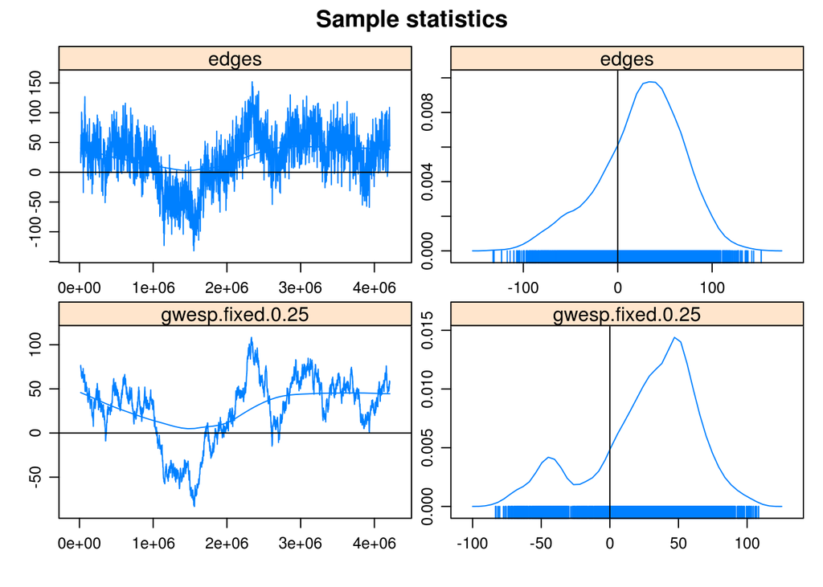

```
##
## Recent changes in the ergm estimation algorithm mean that these plots can no longer be used to ensure that the mean statistics from the model match the observed network statistics. For that functionality, please use the GOF command: gof(ergmFitObject, GOF=~model).
```

Better but still not amazing. Let’s open up the hood with control.ergm and tweak some things to make stuff run better.

First let’s increase the MCMC sample size. This gives our chain more datapoints to play with. The interval increases the gap between each sampling point reducing autocorrelation. We can also add MCMC.burnin which discards however many cases at the start to the modelling process, giving the chain time to settle in.

```r
faux.degen.3 <- ergm(faux.magnolia.high~edges+gwesp(0.25,fixed=T)+nodematch('Grade')+
              nodematch('Race')+nodematch('Sex'),
            control = control.ergm(MCMC.samplesize=50000,MCMC.interval=1000, MCMC.burnin = 5000))
```

```
## Starting maximum likelihood estimation via MCMLE:
## Iteration 1 of at most 20:
## The log-likelihood improved by 5.277
## Step length converged once. Increasing MCMC sample size.
## Iteration 2 of at most 20:
## The log-likelihood improved by 0.2054
## Step length converged twice. Stopping.
##
## This model was fit using MCMC.  To examine model diagnostics and check for degeneracy, use the mcmc.diagnostics() function.
```

```r
mcmc.diagnostics(faux.degen.3)
```

```
## Sample statistics summary:
##
## Iterations = 5000:200004000
## Thinning interval = 1000
## Number of chains = 1
## Sample size per chain = 2e+05
##
## 1. Empirical mean and standard deviation for each variable,
##    plus standard error of the mean:
##
##                   Mean    SD Naive SE Time-series SE
## edges            29.51 50.84  0.11368          2.817
## gwesp.fixed.0.25 26.36 47.03  0.10517          3.832
## nodematch.Grade  28.69 48.70  0.10890          2.956
## nodematch.Race   27.87 46.40  0.10375          2.654
## nodematch.Sex    25.89 41.97  0.09384          2.341
##
## 2. Quantiles for each variable:
##
##                    2.5%    25%   50%   75% 97.5%
## edges            -72.00 -4.000 29.00 64.00 129.0
## gwesp.fixed.0.25 -67.03 -5.016 25.82 57.38 117.5
## nodematch.Grade  -68.00 -4.000 29.00 61.00 125.0
## nodematch.Race   -64.00 -3.000 28.00 59.00 120.0
## nodematch.Sex    -55.00 -3.000 26.00 54.00 108.0
##
##
## Sample statistics cross-correlations:
##                      edges gwesp.fixed.0.25 nodematch.Grade nodematch.Race
## edges            1.0000000        0.8749728       0.9673641      0.9533441
## gwesp.fixed.0.25 0.8749728        1.0000000       0.8928013      0.8684426
## nodematch.Grade  0.9673641        0.8928013       1.0000000      0.9290265
## nodematch.Race   0.9533441        0.8684426       0.9290265      1.0000000
## nodematch.Sex    0.9209451        0.8315295       0.8957999      0.8831562
##                  nodematch.Sex
## edges                0.9209451
## gwesp.fixed.0.25     0.8315295
## nodematch.Grade      0.8957999
## nodematch.Race       0.8831562
## nodematch.Sex        1.0000000
```

[output cut: 20 more lines]

```
##
## Fraction in 1st window = 0.1
## Fraction in 2nd window = 0.5
##
##            edges gwesp.fixed.0.25  nodematch.Grade   nodematch.Race
##           -2.213           -1.703           -2.089           -2.372
##    nodematch.Sex
##           -2.547
##
## Individual P-values (lower = worse):
##            edges gwesp.fixed.0.25  nodematch.Grade   nodematch.Race
##       0.02692990       0.08853579       0.03669111       0.01767653
##    nodematch.Sex
##       0.01086083
## Joint P-value (lower = worse):  0.2860603 .
```

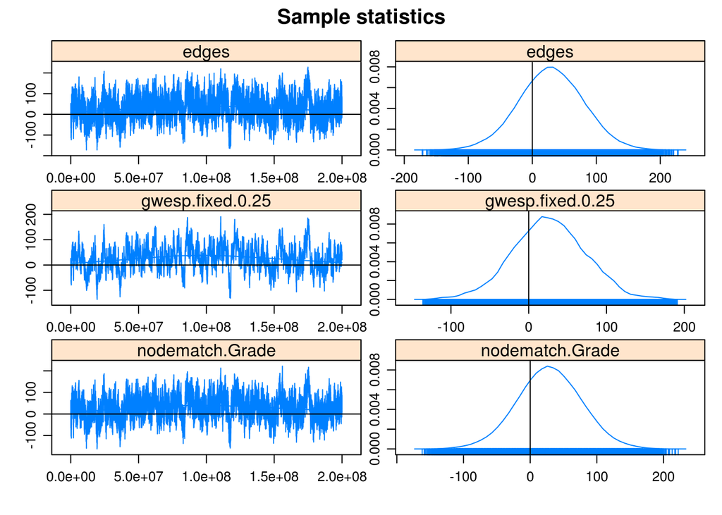

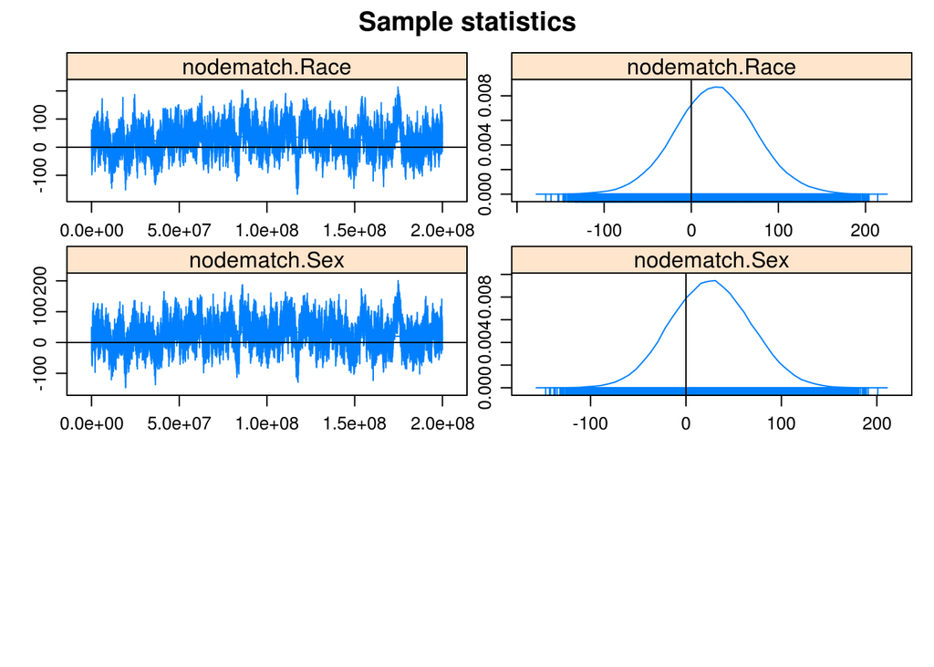

```
##
## Recent changes in the ergm estimation algorithm mean that these plots can no longer be used to ensure that the mean statistics from the model match the observed network statistics. For that functionality, please use the GOF command: gof(ergmFitObject, GOF=~model).
```

Much better! YAY!

Go forth and ERGM.